### **DOCHER Mathieu - IDU4**

# DATA731 - TP1 - Modèles de distributions univariées

## Introduction :

### Analyse n°1 :

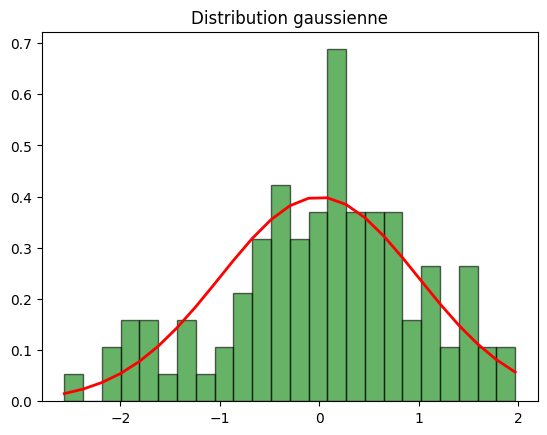

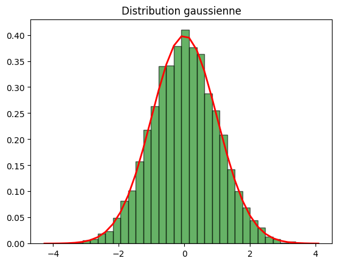

```python
import numpy as np
import matplotlib.pyplot as plt
import random as rd

def Analyse1(µ, σ, N, b=24):
    """
    Génère N échantillons d'une variable aléatoire gaussienne de moyenne µ et d'écart-type σ
    """

    if b not in [12, 24, 36]:
        raise ValueError("b doit être égal à 12, 24 ou 36")

    s = np.random.normal(µ, σ, N)

    # Histogramme
    count, bins, ignored = plt.hist(s, b, density=True, alpha=0.6, color='g', edgecolor='black') # Density=True pour normaliser l'histogramme en une densité de probabilité

    # Fonction de la densité de probabilité
    plt.plot(bins, 1/(σ * np.sqrt(2 * np.pi)) * np.exp( - (bins - µ)**2 / (2 * σ**2) ), linewidth=2, color='r')

    plt.title('Distribution gaussienne')
    plt.show()

Analyse1(µ=0,σ=1,N=100,b=24)
Analyse1(µ=0,σ=1,N=10000,b=36)
```

**Conclusion :** Plus le nombre d'échantillons est grand, plus l'histogramme se rapproche de la courbe de la ddp

### Analyse n°2 :

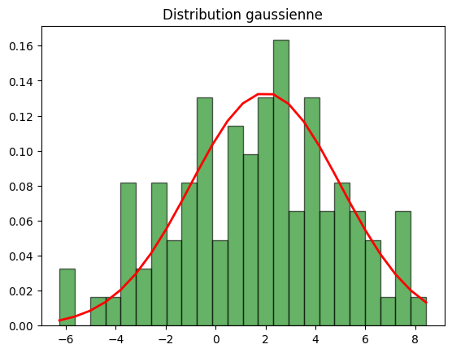

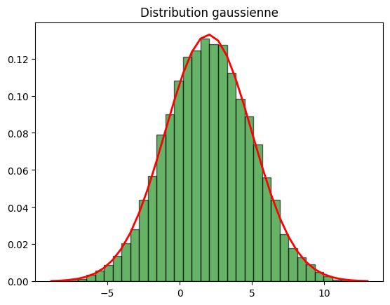

```python
import numpy as np
import matplotlib.pyplot as plt
import random as rd

def Analyse2():
    """
    Juste reprendre l'analyse 1 avec µ = 2, V = 9 donc σ = 3
    """
    Analyse1(µ=2,σ=3,N=100,b=24)
    Analyse1(µ=2,σ=3,N=10000,b=36)

Analyse2()
```

### Analyse n°3 :

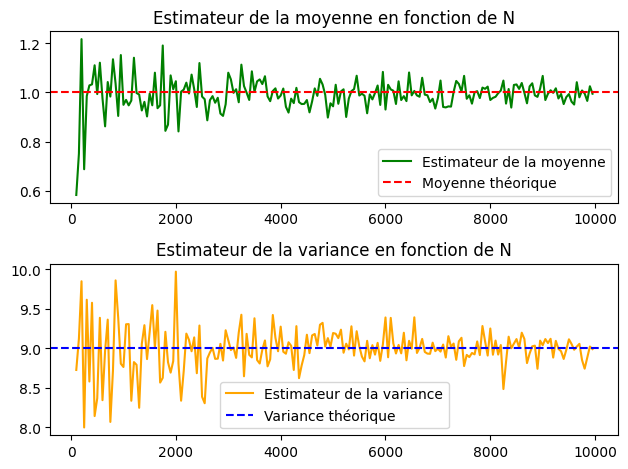

```python
import numpy as np
import matplotlib.pyplot as plt
import random as rd

µ=1
σ=3
N_min=100
N_max=10000
pas=50
b=36

if b not in [12, 24, 36]:
    raise ValueError("b doit être égal à 12, 24 ou 36")

# Estimateurs empiriques
Emean = []
Evar = []

for N in range(N_min, N_max, pas):
    s = np.random.normal(µ, σ, N)
    Emean.append(np.mean(s))
    Evar.append(np.var(s))

fig, (ax1,ax2) = plt.subplots(2,1)
ax1.plot(range(N_min, N_max, pas), Emean, label="Estimateur de la moyenne", color='green')
ax1.axhline(y=µ, color='r', linestyle='--', label="Moyenne théorique")
ax1.legend()
ax1.set_title("Estimateur de la moyenne en fonction de N")

ax2.plot(range(N_min, N_max, pas), Evar, label="Estimateur de la variance", color='orange')
ax2.axhline(y=σ**2, color='b', linestyle='--', label="Variance théorique")
ax2.legend()
ax2.set_title("Estimateur de la variance en fonction de N")

plt.tight_layout()
plt.show()
```

**Conclusion :** Plus N est grand, plus les estimateurs empiriques de la moyenne et de la variance se rapprochent de la vraie moyenne et de la vraie variance

## Exercice 1 : Sélection et validation de modèle univarié

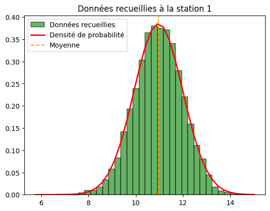

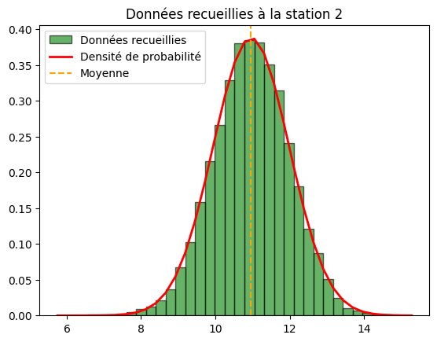

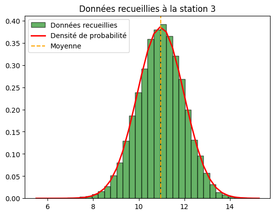

```python
import pandas as pd
import numpy as np
import matplotlib.pyplot as plt

filename = "X_pluv.csv"
# Matrice avec comme fin de colonne ',' et fin de ligne '\n'

df = pd.read_csv(filename)
matrix = df.values

stations = [1,2,3]
s = []
t1 = 0
t2 = len(df.keys())-1

# Histogramme pour chaque ligne k
for k in stations :

    for key in df.keys()[t1:t2]:
        s.append(df[key][k])

    µ = np.mean(s)
    V = np.var(s)
    σ = np.sqrt(V)

    count, bins, ignored = plt.hist(s, 36, density=True, alpha=0.6, color='g', edgecolor='black', label="Données recueillies")

    # Fonction de la densité de probabilité
    plt.plot(bins, 1/(σ * np.sqrt(2 * np.pi)) * np.exp( - (bins - µ)**2 / (2 * σ**2) ), linewidth=2, color='r', label="Densité de probabilité")
    plt.axvline(x=µ, color='orange', linestyle='--', label="Moyenne")
    plt.legend()

    plt.title(f"Données recueillies à la station {k}")
    plt.show()
```

**Conclusion :** On peut observer que les données recueillies dans chacunes de ces stations suivent des lois gaussiennes de moyenne µ=11 et d'écart type σ=1.

## Exercice 2 : Analyse globale par entropie relative

Dans cette exercice, on cherche les dates de changement dans la divergence des données. Dans un premier temps, on calcule chaque entropie, puis on calcule le point où la divergence est maximale. On calcule enfin la moyenne des maximums de divergences de toutes les courbes pour obtenir la date de changement moyenne.

```python
import pandas as pd
import numpy as np
import matplotlib.pyplot as plt

filename = "X_pluv.csv"
# Matrice avec comme fin de colonne ',' et fin de ligne '\n'

df = pd.read_csv(filename)
matrix = df.values

T = 1000

t1 = 200
t2 = T-t1
stations = [i for i in range(0,99)]

tous_Am = []
max_Am = []

for k in stations :
    print(f"Station {k}/{len(stations)}", end="\r")

    X = []
    Am = []

    for key in df.keys():
        X.append(df[key][k])

    m_values = range(t1,t2)

    for m in m_values:
        # u ~ N(µ,σ) = X_k,[:m-1]
        # v ~ N(µ,σ) = X_k,[m+1:]
        u = X[1:m-1]
        v = X[m+1:T]

        µ1 = np.mean(u)
        µ2 = np.mean(v)
        v1 = np.var(u, ddof=1)
        v2 = np.var(v, ddof=1)

    # if v1!=0 and v2!=0:
        # A(m) = D(u,v) = 1/2 * (µ(u) - µ(v))^2/(σ(u)^2 + σ(v)^2) + 1/2 * (σ(u)^2/σ(v)^2 + σ(v)^2/σ(u)^2) - 1
        d = 1/2 * (µ1 - µ2)**2/(v1 + v2) + 1/2 * (v1/v2 + v2/v1) - 1
        Am.append(d)

    max_Am.append(Am.index(max(Am))+t1)
    tous_Am.append(Am)

plt.figure(figsize=(10,6))

for index,am in enumerate(tous_Am):
    plt.plot(m_values,am)

moyenne_max_Am = np.mean(max_Am)
print("Moyenne de changement : " + str(moyenne_max_Am), end="\r")
plt.axvline(x=moyenne_max_Am, color='orange', linestyle='--', label="Am max")

plt.title(f"Am pour toutes les stations")
plt.xlabel("m")
plt.ylabel("Am")

plt.show()
```

**Conclusion :**

En exécutant le programme ci-dessous pour les 10000 échantillons, on obtient le graphe ci-dessous et la moyenne de m = 283 pour la date de changement :

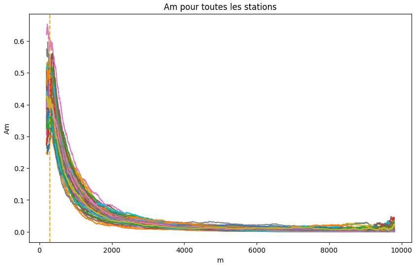

Cependant, la stabilité des dernières variables fausse le résultat. En effet, en ne prenant en compte que les 1000 premiers élements, on obteint le graphe ci-dessous et une moyenne de m = 356. Ce résultat est plus fiable car il ne prend en compte que la partie où les mesures varient.

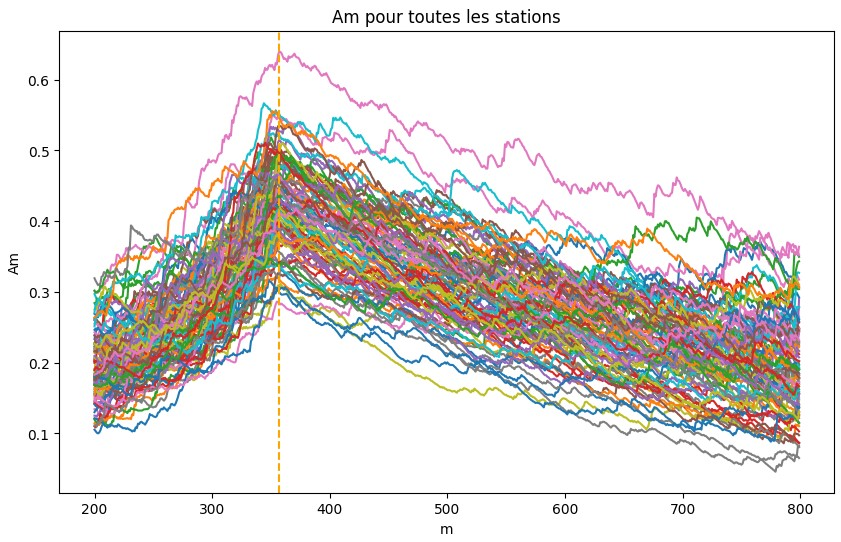

## Exercice 3 : Analyse locale par entropie relative

Comme dans l'exercice précédent, on cherche les dates de changement dans la divergence des données. Cependant, cette fois-ci, on utilise une fenêtre glissante pour calculer les entropies plus localement. On calcule ensuite la date moyenne des maximums d'entropie de toutes les courbes pour obtenir la date de changement moyenne.

```python
import pandas as pd
import numpy as np
import matplotlib.pyplot as plt

filename = "X_pluv.csv"
# Matrice avec comme fin de colonne ',' et fin de ligne '\n'

df = pd.read_csv(filename)
matrix = df.values

T = 1000

p = 100
t1 = 200
t2 = T-t1
stations = [i for i in range(0,99)]

tous_Am = []
max_Am = []

for k in stations :
    print(f"Station {k}/{len(stations)}", end="\r")

    X = []
    Am = []

    for key in df.keys():
        X.append(df[key][k])

    m_values = range(t1,t2)

    for m in m_values:
        # u ~ N(µ,σ) = X_k,[:m-1]
        # v ~ N(µ,σ) = X_k,[m+1:]
        u = X[m-p:m-1]
        v = X[m+1:m+p]

        µ1 = np.mean(u)
        µ2 = np.mean(v)
        v1 = np.var(u, ddof=1)
        v2 = np.var(v, ddof=1)

    # if v1!=0 and v2!=0:
        # A(m) = D(u,v) = 1/2 * (µ(u) - µ(v))^2/(σ(u)^2 + σ(v)^2) + 1/2 * (σ(u)^2/σ(v)^2 + σ(v)^2/σ(u)^2) - 1
        d = 1/2 * (µ1 - µ2)**2/(v1 + v2) + 1/2 * (v1/v2 + v2/v1) - 1
        Am.append(d)

    max_Am.append(Am.index(max(Am))+t1)
    tous_Am.append(Am)

plt.figure(figsize=(10,6))

for index,am in enumerate(tous_Am):
    plt.plot(m_values,am)

moyenne_max_Am = np.mean(max_Am)
print("Moyenne de changement : " + str(moyenne_max_Am), end="\r")
plt.axvline(x=moyenne_max_Am, color='orange', linestyle='--', label="Am max")

plt.title(f"Am pour toutes les stations")
plt.xlabel("m")
plt.ylabel("Am")

plt.show()
```

**Conclusion :**

Comme dans l'exercice précédent, le résultat sur 10000 échantillons n'est pas très fiable (1er grpahe ci-dessous). Il est préférable d'utiliser seulement les 1000 premiers échantillons (qui ont des variations plus importantes) (deuxième graphie ci-dessous). Avec seulement 1000 échantillons et une analyse locale (p=100), on obtient une date de changement moyenne m = 362. Par contre, il est possible de voir que l'intensité des variations est plus importante lorsqu'on analyse localement, car les pics sont beaucoup plus prononcés.

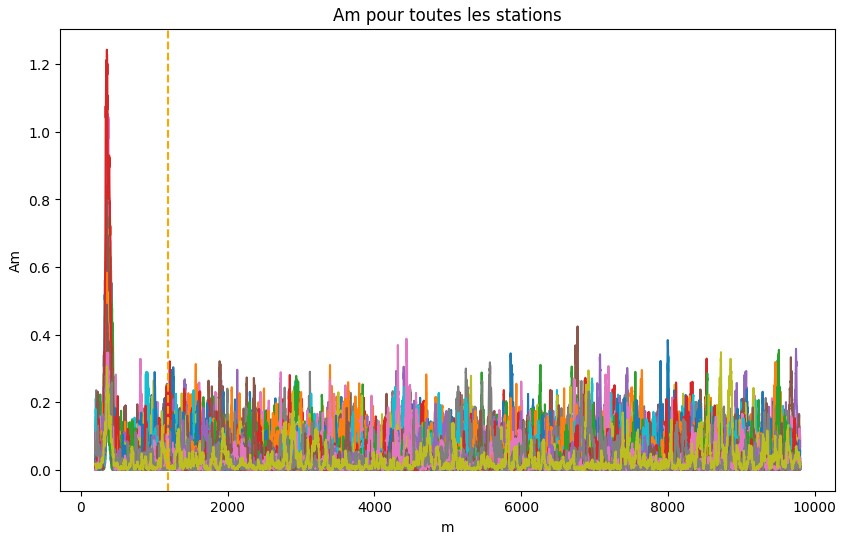

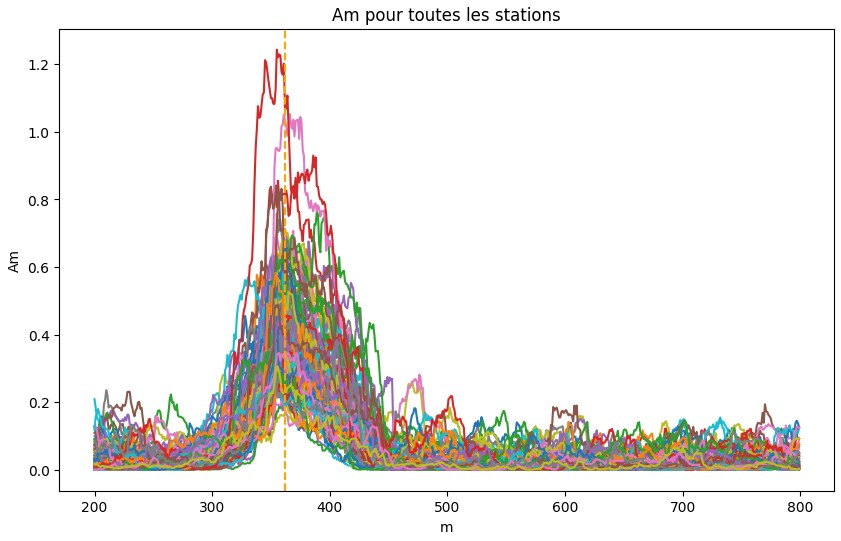